# Hypothesize and Cluster Iris dataset by using R

최호진(gansaw12@gmail.com)

2023.07.10(월)

# I. 서론

- 유명 데이터셋인 Iris를 활용하여 가설검정을 진행한다. 유의수준(α)는 0.05(5%)로 진항하였다.
- 가설검정 결과 귀무가설을 기각하는 항목을 추출한다.
- 거리법을 통해 최적의 군집 수(k)를 구하고 k-means 군집분석을 진행한다.
- 분석 결과를 결론 항목에 도출한다.

## a. 패키지

```r
install.packages("tidyverse")
install.packages("NbClust")
install.packages("cluster")
```

```r
library(tidyverse)
library(NbClust)
library(cluster)
```

# II. 탐색적 데이터 분석(EDA)

> 전처리 및 데이터 분석을 진행하기 전 데이터셋이 어떻게 구성되어있는지 확인해야 한다. iris 데이터를 불러오고 전반적인 구조를 파악한다.

```r
df_iris <- iris     # Iris 데이터를 불러온다.
```

```r
colnames(df_iris)     # Iris 열의 이름을 확인할 수 있다.
```

```
## [1] "Sepal.Length" "Sepal.Width"  "Petal.Length" "Petal.Width"  "Species"
```

```r
head(df_iris)     # Iris 열 상위 6개를 확인할 수 있다.
```

|  | Sepal.Length | Sepal.Width | Petal.Length | Petal.Width | Species |
| --- | --- | --- | --- | --- | --- |
| 1 | 5.1 | 3.5 | 1.4 | 0.2 | setosa |
| 2 | 4.9 | 3.0 | 1.4 | 0.2 | setosa |
| 3 | 4.7 | 3.2 | 1.3 | 0.2 | setosa |
| 4 | 4.6 | 3.1 | 1.5 | 0.2 | setosa |
| 5 | 5.0 | 3.6 | 1.4 | 0.2 | setosa |
| 6 | 5.4 | 3.9 | 1.7 | 0.4 | setosa |

```r
str(df_iris)     # Iris 데이터의 형태를 확인할 수 있다.
```

```
## 'data.frame':    150 obs. of  5 variables:
##  $ Sepal.Length: num  5.1 4.9 4.7 4.6 5 5.4 4.6 5 4.4 4.9 ...
##  $ Sepal.Width : num  3.5 3 3.2 3.1 3.6 3.9 3.4 3.4 2.9 3.1 ...
##  $ Petal.Length: num  1.4 1.4 1.3 1.5 1.4 1.7 1.4 1.5 1.4 1.5 ...
##  $ Petal.Width : num  0.2 0.2 0.2 0.2 0.2 0.4 0.3 0.2 0.2 0.1 ...
##  $ Species     : Factor w/ 3 levels "setosa","versicolor",..: 1 1 1 1 1 1 1 1 1 1 ...
```

```r
summary(df_iris)     # Iris의 요약본을 확인할 수 있다.
```

```
##   Sepal.Length    Sepal.Width     Petal.Length    Petal.Width
##  Min.   :4.300   Min.   :2.000   Min.   :1.000   Min.   :0.100
##  1st Qu.:5.100   1st Qu.:2.800   1st Qu.:1.600   1st Qu.:0.300
##  Median :5.800   Median :3.000   Median :4.350   Median :1.300
##  Mean   :5.843   Mean   :3.057   Mean   :3.758   Mean   :1.199
##  3rd Qu.:6.400   3rd Qu.:3.300   3rd Qu.:5.100   3rd Qu.:1.800
##  Max.   :7.900   Max.   :4.400   Max.   :6.900   Max.   :2.500
##        Species
##  setosa    :50
##  versicolor:50
##  virginica :50
##
##
##
```

Iris의 데이터는 다음과 같이 분류되어 있다. 1. Sepal - length, width 2. Petal - length, width 3. Species - setosa, versicolor, virginica

위 데이터를 이용하여 가설검정 및 데이터 분석을 진행하여야 하는데 그 전의 과정이 필요하다. 바로 데이터 전처리 과정이다.

# III. 데이터 전처리 (Data preprocessing)

> 데이터를 파악한 이후 데이터 전처리를 수항할 때 가장 먼저 하는 일은 결측치, 이상치를 처리하는 일이다.

## a. 결측치 처리

결측치를 처리하기 위해서는 결측치를 제거하거나 정제하는 방법이 있다. 결측치 유무를 확인하는 코드를 작성한 결과 결측치는 존재하지 않았다. 이에 따라 따로 제거하거나 정제하는 과정은 거치지 않았다.

```r
table(is.na(df_iris))
```

```
##
## FALSE
##   750
```

## b. 이상치 처리

데이터 분석의 정확성을 향상시키고 모델의 안정화를 위해 이상치를 처리하여야 한다. 이상치를 처리하는 방법은 여러가지 있는데 그 중에서 z-score normalization을 사용하기로 하였다.

```r
# 변수 추출

library(tidyverse)
```

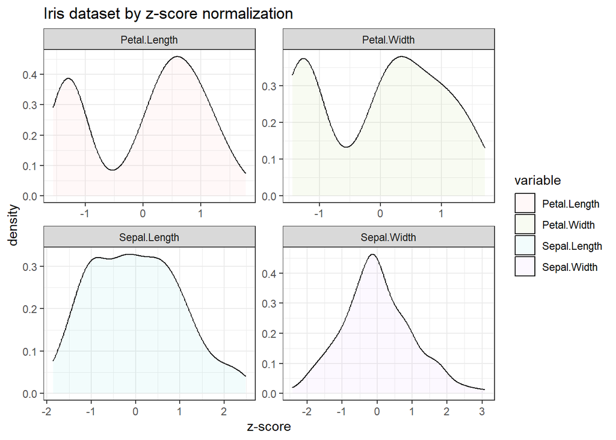

```r
vars <- names(df_iris)[1:4]

# z-score 정규화
zscore_iris <- df_iris %>%
  mutate(across(all_of(vars), scale))

# 데이터 프레임으로 변환
df_zscore_iris <- as.data.frame(zscore_iris)

# 그래프 생성

df_zscore_iris %>%
  pivot_longer(cols = all_of(vars), names_to = "variable", values_to = "value") %>%
  ggplot(aes(x = value)) +
  geom_density(aes(fill = variable), alpha = 0.05) +     # 유의수준(alpha) 5% 이내
  facet_wrap(~ variable, scales = "free") +
  labs(title = "Iris dataset by z-score normalization", x = "z-score", y = "density") +
  theme_bw()
```

일반적으로 표준편차가 3 이상이거나 -3 미만인 경우 일반적으로 이상치로 구분한다. 이상치를 처리한 결과 다음과 같다.

```r
filtered_iris <- iris[abs(zscore_iris[1:4]) < 3, ]     # 이상치들을 NA로 전환한다.
filtered_iris <- na.omit(filtered_iris)     # NA값을 제거한다.
head(filtered_iris)
```

|  | Sepal.Length | Sepal.Width | Petal.Length | Petal.Width | Species |
| --- | --- | --- | --- | --- | --- |
| 1 | 5.1 | 3.5 | 1.4 | 0.2 | setosa |
| 2 | 4.9 | 3.0 | 1.4 | 0.2 | setosa |
| 3 | 4.7 | 3.2 | 1.3 | 0.2 | setosa |
| 4 | 4.6 | 3.1 | 1.5 | 0.2 | setosa |
| 5 | 5.0 | 3.6 | 1.4 | 0.2 | setosa |
| 6 | 5.4 | 3.9 | 1.7 | 0.4 | setosa |

# IV. 가설검정

> 현재 Species를 살펴보면 품종이 3종류로 구성되어 있다. 따라서 3품종 간 차이를 검정하기 위해서 분산분석(ANOVA)를 이용하여 가설검정을 진행하였다. 그리고 factor가 Species 1개이기 때문에 분산분석 중 일원분산분석을 이용하였다.

## a. Sepal.Length - Species

```r
lm.sl_filtered_iris <- lm(Sepal.Length ~ factor(Species), data = filtered_iris)
anova_sl_result <- anova(lm.sl_filtered_iris)

print(anova_sl_result)
```

```
## Analysis of Variance Table
##
## Response: Sepal.Length
##                  Df Sum Sq Mean Sq F value    Pr(>F)
## factor(Species)   2 63.212  31.606  119.26 < 2.2e-16 ***
## Residuals       147 38.956   0.265
## ---
## Signif. codes:  0 '***' 0.001 '**' 0.01 '*' 0.05 '.' 0.1 ' ' 1
```

## b. Sepal.Width - Species

```r
lm.sw_filtered_iris <- lm(Sepal.Width ~ factor(Species), data = filtered_iris)
anova_sw_result <- anova(lm.sw_filtered_iris)

print(anova_sw_result)
```

```
## Analysis of Variance Table
##
## Response: Sepal.Width
##                  Df Sum Sq Mean Sq F value    Pr(>F)
## factor(Species)   2 11.345  5.6725   49.16 < 2.2e-16 ***
## Residuals       147 16.962  0.1154
## ---
## Signif. codes:  0 '***' 0.001 '**' 0.01 '*' 0.05 '.' 0.1 ' ' 1
```

## c. Petal.Length - Species

```r
lm.pl_filtered_iris <- lm(Petal.Length ~ factor(Species), data = filtered_iris)
anova_pl_result <- anova(lm.pl_filtered_iris)

print(anova_pl_result)
```

```
## Analysis of Variance Table
##
## Response: Petal.Length
##                  Df Sum Sq Mean Sq F value    Pr(>F)
## factor(Species)   2 437.10 218.551  1180.2 < 2.2e-16 ***
## Residuals       147  27.22   0.185
## ---
## Signif. codes:  0 '***' 0.001 '**' 0.01 '*' 0.05 '.' 0.1 ' ' 1
```

## d. Petal.Width - Species

```r
lm.pw_filtered_iris <- lm(Petal.Width ~ factor(Species), data = filtered_iris)
anova_pw_result <- anova(lm.pw_filtered_iris)

print(anova_pw_result)
```

```
## Analysis of Variance Table
##
## Response: Petal.Width
##                  Df Sum Sq Mean Sq F value    Pr(>F)
## factor(Species)   2 80.413  40.207  960.01 < 2.2e-16 ***
## Residuals       147  6.157   0.042
## ---
## Signif. codes:  0 '***' 0.001 '**' 0.01 '*' 0.05 '.' 0.1 ' ' 1
```

## e. 가설검정 결과

> 4가지 가설 모두 Pr(>F) 부분이 다음과 같이 출력된다. (2.2e-16 ***) Signif. codes: 0 ‘**’ 0.001 ‘**’ 0.01 ‘’ 0.05 ‘.’ 0.1 ‘ ’ 1 를 참조하면 위 가설 모두 유의수준 0.001 이내에서 매우 통계적으로 유의하다는 것을 알 수 있다. 따라서 귀무가설을 기각하고 연구가설을 채택한다. => 결론 : 꽃받침(길이, 너비), 꽃잎(길이, 너비) 모두 품종과 관련이 있다.

# V. 군집분석

> 그렇다면 실제로 위 가설이 검증되었는지 확인하기 위해 군집분석을 진행하였다. set.seed를 통해 난수를 생성하고 난수를 생성한 결과 군집이 제대로 이루어지는지 가장 보편적으로 사용하는 k-means군집분석을 이용하였다. k-means 군집분석은 주어진 데이터를 k개의 클러스터로 그룹화하는 비지도 학습 기법이다. 이 알고리즘은 데이터 포인트들을 각각 가장 가까운 중심점(centroid)으로 할당하고, 할당된 포인트들을 기반으로 새로운 중심점을 계산하는 과정을 반복하여 클러스터의 중심점을 최적화하는 과정을 거친다.

```r
library(NbClust)

# 사용할 데이터셋 지정 (Species는 사용하지 않으므로 제외한다)
df_iris2 <- filtered_iris[,-5]

# 랜덤으로 표본을 뽑는 규칙 설정 => 일관된 결과를 얻을 수 있다.
set.seed(1234)
nc2 <- NbClust(df_iris2, distance="euclidean", min.nc=3, max.nc=15, method="kmeans")
```

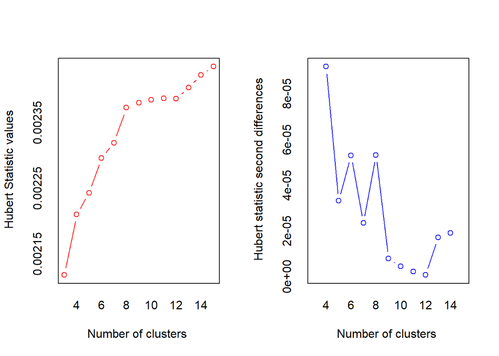

```
## *** : The Hubert index is a graphical method of determining the number of clusters.
##                 In the plot of Hubert index, we seek a significant knee that corresponds to a
##                 significant increase of the value of the measure i.e the significant peak in Hubert
##                 index second differences plot.
##
```

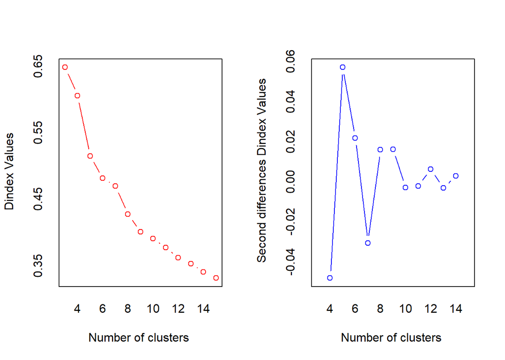

```
## *** : The D index is a graphical method of determining the number of clusters.
##                 In the plot of D index, we seek a significant knee (the significant peak in Dindex
##                 second differences plot) that corresponds to a significant increase of the value of
##                 the measure.
##
## * Among all indices:
## * 10 proposed 3 as the best number of clusters
## * 5 proposed 4 as the best number of clusters
## * 4 proposed 5 as the best number of clusters
## * 1 proposed 6 as the best number of clusters
## * 1 proposed 8 as the best number of clusters
## * 1 proposed 9 as the best number of clusters
## * 1 proposed 12 as the best number of clusters
##
##                    ***** Conclusion *****
##
## * According to the majority rule, the best number of clusters is  3
##
##
```

the best number of clusters is 3 이라는 문구를 통해 최적의 k값은 3이라는 것을 확인할 수 있었다. 이제 이 k 값을 이용하여 clustering을 진행하였다.

## a. 분석 결과

```r
km_iris2 <- kmeans(df_iris2, centers=3, nstart=10)     # nstart: iteration 횟수 제약을 의미한다.
km_iris2
```

```
## K-means clustering with 3 clusters of sizes 50, 38, 62
##
## Cluster means:
##   Sepal.Length Sepal.Width Petal.Length Petal.Width
## 1     5.006000    3.428000     1.462000    0.246000
## 2     6.850000    3.073684     5.742105    2.071053
## 3     5.901613    2.748387     4.393548    1.433871
##
## Clustering vector:
##   1   2   3   4   5   6   7   8   9  10  11  12  13  14  15  16  17  18  19  20
##   1   1   1   1   1   1   1   1   1   1   1   1   1   1   1   1   1   1   1   1
##  21  22  23  24  25  26  27  28  29  30  31  32  33  34  35  36  37  38  39  40
##   1   1   1   1   1   1   1   1   1   1   1   1   1   1   1   1   1   1   1   1
##  41  42  43  44  45  46  47  48  49  50  51  52  53  54  55  56  57  58  59  60
##   1   1   1   1   1   1   1   1   1   1   3   3   2   3   3   3   3   3   3   3
##  61  62  63  64  65  66  67  68  69  70  71  72  73  74  75  76  77  78  79  80
##   3   3   3   3   3   3   3   3   3   3   3   3   3   3   3   3   3   2   3   3
##  81  82  83  84  85  86  87  88  89  90  91  92  93  94  95  96  97  98  99 100
##   3   3   3   3   3   3   3   3   3   3   3   3   3   3   3   3   3   3   3   3
## 101 102 103 104 105 106 107 108 109 110 111 112 113 114 115 116 117 118 119 120
##   2   3   2   2   2   2   3   2   2   2   2   2   2   3   3   2   2   2   2   3
## 121 122 123 124 125 126 127 128 129 130 131 132 133 134 135 136 137 138 139 140
##   2   3   2   3   2   2   3   3   2   2   2   2   2   3   2   2   2   2   3   2
## 141 142 143 144 145 146 147 148 149 150
##   2   2   3   2   2   2   3   2   2   3
##
## Within cluster sum of squares by cluster:
## [1] 15.15100 23.87947 39.82097
##  (between_SS / total_SS =  88.4 %)
##
## Available components:
##
## [1] "cluster"      "centers"      "totss"        "withinss"     "tot.withinss"
## [6] "betweenss"    "size"         "iter"         "ifault"
```

## b. 시각화

군집분석을 clusplot을 이용하여 시각화하였다.

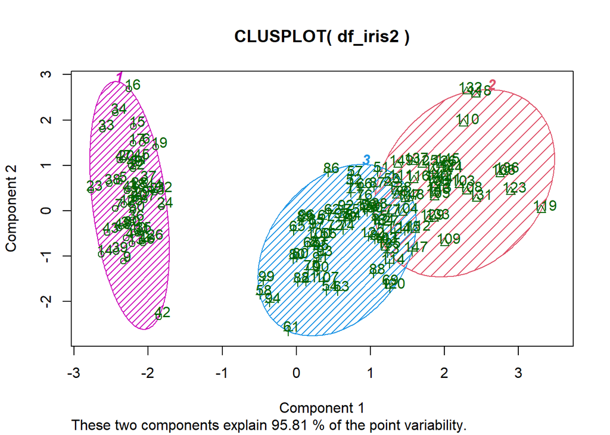

```r
# clusplot
library(cluster)
clusplot(x=df_iris2, clus=km_iris2$cluster, color=T, shade=T, labels=2, lines=0)
```

# VI. 결론

> NbClust를 통해 최적의 k값을 결정하였고 k-means 알고리즘을 적용하여 데이터 포인트가 3개의 cluster로 구분되었다. 그리고 시각화를 통해 cluster 간 분포와 경계를 확인할 수 있었다. 위 clusplot을 통해 두 구성요소 간 95.81%로 변동성에 영향이 강하다는 것을 확인할 수 있다. 다시 말하자면 위 모델은 데이터셋의 구조를 잘 요약하고 있다는 것을 의미한다. 따라서 위 모델을 통해 데이터의 구조와 패턴을 파악하는데 도움이 되었고 위 clustering을 통하여 추가적인 분석이나 의사결정에 활용되는데 도움을 줄 수 있다고 볼 수 있다.